# Time dependent AUC with survival data _ correct4

Hwang Seong-Yun

2022 4 22

# Loading packages

```r
library(survival)
library(timeROC)
library(timereg)
library(ggplot2)
library(reshape)
library(plyr)
library(tidyverse)
library(coxed)
library(gridExtra)
```

# Generating simulation data from Cox Regression Model

## Background

- reference 1 : https://doi.org/10.5351/KJAS.2018.31.6.761
- reference 2 : https://doi.org/10.1017/psrm.2018.19

`-` real survival time $Y$ : Exponential distribution

`-` censoring time $C$ : Uniform distribution

- $h(t|x)=h_{0}(t)exp(f(x))$
- $H(t|x)=\int_{0}^{t} h(s|x)ds= \int_{0}^{t} h_{0}(s)exp(f(x))ds=H_{0}(t)exp(f(x))$
- $h(t|x)=\frac {f(t|x)}{S(t|x)}= -\frac {d}{dt} log[S(t|x)]$
- $log[S(t|x)]= -\int_{0}^{t} h(s|x)ds= -H(t|x)= -H_{0}(t)exp(f(x))$
- $S(t|x)=exp[-H_{0}(t)exp(f(x))]$
- In general,…
- $F(t|x)=1-exp[-H_{0}(t) exp(f(x))]$
- -> $F^{-1}(t|x)=H_{0}^{-1}[-log(1-t) exp(-f(x))]$
- By Inverse Transform Sampling, suppose that $U_{1}, U_{2} \overset{i.i.d}{\sim}\ U(0,1)$, then we can generate real survival time $Y$ from Cox Regression Model using this equation.
- $Y=H_{Y0}^{-1}[-log(U_{1})exp(-f(x))]$
- And by assuming non-informative censoring, we can generate censoring time $C$ like this equation. (Set $Y$ and $C$ are independent each other.)
- $C=H_{C0}^{-1}[-log(U_{2})]$
- And set censoring indicator $\delta=I(Y \leq C)$ and observed survival time $T=min(Y,C)$
- $H_{Y0}(t)$ : Basis cumulative hazard function of real survival time $Y$
- $H_{C0}(t)$ : Basis cumulative hazard function of censoring time $C$
- When parametric basis distribution of real survival time $Y$ is Exponential distribution and parametric basis distribution of censoring time $C$ is Uniform distribution ($Y$ and $C$ are independent each other), then ~
- $Y$ : $f_{Y0}(t)=\lambda e^{-\lambda t}, t>0$ -> $S_{Y0}(t)=e^{-\lambda t}$ -> $h_{Y0}(t)=\lambda$
- $C$ : $f_{C0}(t)=\frac {1}{\lambda}, 0<t<\lambda$ -> $S_{C0}(t)=1-\frac {t}{\lambda}$ -> $h_{C0}(t)=\frac {1}{\lambda -t}$
- $\therefore Y=-\frac{1}{\lambda_{1}} log(U_{1}) exp(-f(x))$, $C=\lambda_{2}(1-U_{2})$

## Generating simulation data

## Assume linear relationship

```r
# Assume parametric basis distribution is Exponential distribution...
lambda1 <- 0.001 # parameter for generate Y
lambda2 <- 1.5/lambda1 # parameter for generate C
beta1 <- 3 # true coefficients
Y <- c() # real survival time
C <- c() # censoring time
t <- c() # observed survival time
censor <- c() # censoring indicator
X <- c() # explanatory variable
U1 <- c() # random variable from U(0,1) for generate Y
U2 <- c() # random variable from U(0,1) for generate C
X2 <- c() # X^2

for (i in 1:200) {
  U1[i] <- runif(1)
  U2[i] <- runif(1)
  X[i] <- rnorm(1,mean=0,sd=1)
  X2[i] <- X[i]^2
  Y[i] <- -(1/lambda1)*log(U1[i])*exp(-beta1*X[i])
  C[i] <- (lambda2)*(1-U2[i])
  t[i] <- min(Y[i],C[i])
  censor[i] <- ifelse(Y[i]<=C[i],1,0)
}

mean(1-censor) # censoring rate
```

```
## [1] 0.51
```

```r
dt3 <- data.frame(X=X, X2=X2, Y=Y, C=C, time=t, censor=censor)
head(dt3,10)
```

```
##             X        X2            Y         C       time censor
## 1  -0.3361336 0.1129858  1017.462489  820.0747 820.074712      0
## 2   0.9194913 0.8454643    36.005762 1051.9145  36.005762      1
## 3   1.4772471 2.1822590    26.483594 1122.0475  26.483594      1
## 4  -0.4382376 0.1920522   232.661361  255.4397 232.661361      1
## 5   0.4419050 0.1952800   294.106003  868.8987 294.106003      1
## 6   0.3574100 0.1277419   780.159761 1399.7767 780.159761      1
## 7   0.7442447 0.5539002    23.733879  388.7692  23.733879      1
## 8   1.0352154 1.0716710     6.460773  882.0718   6.460773      1
## 9   0.5425353 0.2943446    58.732767  568.8461  58.732767      1
## 10 -0.4429310 0.1961879 10889.379942  280.2626 280.262580      0
```

```r
min(dt3$time[dt3$censor==1])
```

```
## [1] 0.03773885
```

### True model

- $h(t|x)=h _{0} (t)exp[f(x)]$
- $f(x)=\beta_{1} x$
- True coefficients : $\beta_{1}=3$

### Set linear model

- $h(t|x)=h _{0} (t)exp[f(x)]$
- $f(x)=\beta_{1}x$

```r
cox.lin.dt3 <- coxph(Surv(time,censor) ~ X, data=dt3)
summary(cox.lin.dt3)
```

```
## Call:
## coxph(formula = Surv(time, censor) ~ X, data = dt3)
##
##   n= 200, number of events= 98
##
##      coef exp(coef) se(coef)     z Pr(>|z|)
## X  2.8799   17.8119   0.2259 12.75   <2e-16 ***
## ---
## Signif. codes:  0 '***' 0.001 '**' 0.01 '*' 0.05 '.' 0.1 ' ' 1
##
##   exp(coef) exp(-coef) lower .95 upper .95
## X     17.81    0.05614     11.44     27.73
##
## Concordance= 0.907  (se = 0.014 )
## Likelihood ratio test= 277.4  on 1 df,   p=<2e-16
## Wald test            = 162.5  on 1 df,   p=<2e-16
## Score (logrank) test = 220.6  on 1 df,   p=<2e-16
```

```r
risk.lin.dt3 <- predict(object=cox.lin.dt3, newdata=dt3, type="risk") # risk score
dt3$risk.lin.dt3 <- risk.lin.dt3
ROC.risk.lin.dt3 <- timeROC(T=dt3$time,
                         delta=dt3$censor,marker=dt3$risk.lin.dt3,
                         cause=1,weighting="marginal",
                         times=dt3$time)
ROC.risk.lin.dt3
```

```
## Time-dependent-Roc curve estimated using IPCW  (n=200, without competing risks).
##                      Cases Survivors Censored AUC (%)
## t=0.0377388539813192     0       199        1      NA
## t=36.005762323975       43       149        8   94.92
## t=232.661360806711      75       100       25   95.82
## t=591.228451346979      90        50       60   95.12
## t=1489.94141269941      98         0      102      NA
##
## Method used for estimating IPCW:marginal
##
## Total computation time : 0.05  secs.
```

### Set quadratic model

- $h(t|x)=h _{0} (t)exp[f(x)]$
- $f(x)=\beta_{1}x+\beta_{2}x^2$

```r
cox.quad.dt3 <- coxph(Surv(time,censor) ~ X+X2, data=dt3)
summary(cox.quad.dt3)
```

```
## Call:
## coxph(formula = Surv(time, censor) ~ X + X2, data = dt3)
##
##   n= 200, number of events= 98
##
##        coef exp(coef) se(coef)      z Pr(>|z|)
## X   2.99355  19.95648  0.33916  8.826   <2e-16 ***
## X2 -0.07558   0.92720  0.16219 -0.466    0.641
## ---
## Signif. codes:  0 '***' 0.001 '**' 0.01 '*' 0.05 '.' 0.1 ' ' 1
##
##    exp(coef) exp(-coef) lower .95 upper .95
## X    19.9565    0.05011   10.2658    38.795
## X2    0.9272    1.07851    0.6747     1.274
##
## Concordance= 0.907  (se = 0.014 )
## Likelihood ratio test= 277.7  on 2 df,   p=<2e-16
## Wald test            = 159.8  on 2 df,   p=<2e-16
## Score (logrank) test = 421.6  on 2 df,   p=<2e-16
```

```r
risk.quad.dt3 <- predict(object=cox.quad.dt3, newdata=dt3, type="risk") # risk score
dt3$risk.quad.dt3 <- risk.quad.dt3
ROC.risk.quad.dt3 <- timeROC(T=dt3$time,
                         delta=dt3$censor,marker=dt3$risk.quad.dt3,
                         cause=1,weighting="marginal",
                         times=dt3$time)
ROC.risk.quad.dt3
```

```
## Time-dependent-Roc curve estimated using IPCW  (n=200, without competing risks).
##                      Cases Survivors Censored AUC (%)
## t=0.0377388539813192     0       199        1      NA
## t=36.005762323975       43       149        8   94.92
## t=232.661360806711      75       100       25   95.82
## t=591.228451346979      90        50       60   95.12
## t=1489.94141269941      98         0      102      NA
##
## Method used for estimating IPCW:marginal
##
## Total computation time : 0.02  secs.
```

#### Make AUC data

```r
# uncensored
uncensored.density3 <- density(dt3$time[dt3$censor==1])
data3_1 <- data.frame(time=uncensored.density3[["x"]],
                    density=uncensored.density3[["y"]])
data3_1$density.adjusted <- (max(na.omit(ROC.risk.lin.dt3[["AUC"]]))-min(na.omit(ROC.risk.lin.dt3[["AUC"]])))*(uncensored.density3[["y"]]-min(uncensored.density3[["y"]]))/(max(uncensored.density3[["y"]])-min(uncensored.density3[["y"]]))+min(na.omit(ROC.risk.lin.dt3[["AUC"]]))

# censored
censored.density3 <- density(dt3$time[dt3$censor==0])
data3_2 <- data.frame(time=censored.density3[["x"]],
                    density=censored.density3[["y"]])
data3_2$density.adjusted <- (max(na.omit(ROC.risk.lin.dt3[["AUC"]]))-min(na.omit(ROC.risk.lin.dt3[["AUC"]])))*(censored.density3[["y"]]-min(censored.density3[["y"]]))/(max(censored.density3[["y"]])-min(censored.density3[["y"]]))+min(na.omit(ROC.risk.lin.dt3[["AUC"]]))

res3 <- data.frame(time=ROC.risk.lin.dt3[["times"]],
                    cox.lin.dt3=ROC.risk.lin.dt3[["AUC"]],
                    cox.quad.dt3=ROC.risk.quad.dt3[["AUC"]])
res3 <- melt(data = res3,
                   id.vars = "time",
                   measure.vars = c("cox.lin.dt3","cox.quad.dt3"))
```

#### Time dependent AUC plot with ggplot2 (cox.lin.dt3, cox.quad.dt3)

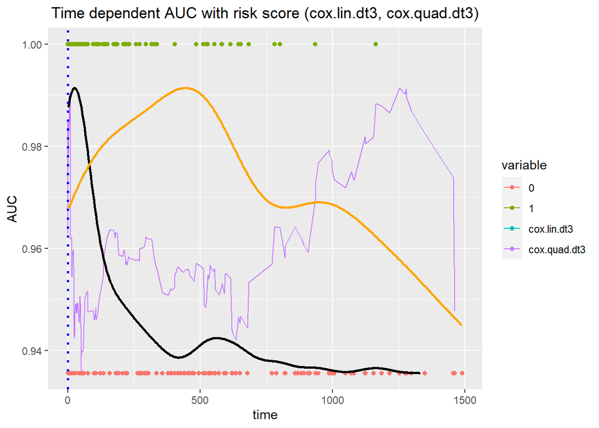

```r
dt3$censor1 <- ifelse(dt3$censor==1,
                    1,min(na.omit(ROC.risk.lin.dt3[["AUC"]])))
ggplot() +
  geom_line(data=res3, aes(x=time, y=value,
                            group=variable, color=variable)) +
  geom_point(data=dt3, aes(x=time, y=censor1, color=as.factor(censor))) +
  geom_line(data=data3_1, aes(x=time, y=density.adjusted),
            size=1, colour='black') +
  geom_line(data=data3_2, aes(x=time, y=density.adjusted),
            size=1, colour='orange') +
  scale_x_continuous(limits = c(0, max(dt3$time))) +
  geom_vline(xintercept = min(dt3$time[dt3$censor==1]),
             linetype="dotted", color = "blue", size=1) +
  ggtitle("Time dependent AUC with risk score (cox.lin.dt3, cox.quad.dt3)") +
  xlab("time") + ylab("AUC") +
  theme(plot.title = element_text(hjust = 0.5))
```

```
## geom_path: Each group consists of only one observation. Do you need to adjust
## the group aesthetic?
```

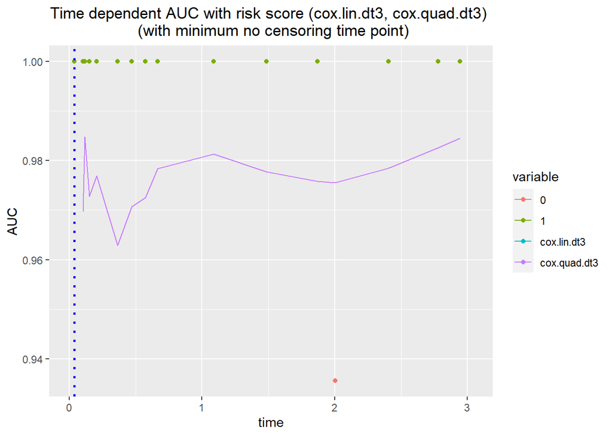

```r
ggplot() +
  geom_line(data=res3, aes(x=time, y=value,
                            group=variable, color=variable)) +
  geom_point(data=dt3, aes(x=time, y=censor1, color=as.factor(censor))) +
  geom_line(data=data3_1, aes(x=time, y=density.adjusted),
            size=1, colour='black') +
  geom_line(data=data3_2, aes(x=time, y=density.adjusted),
            size=1, colour='orange') +
  scale_x_continuous(limits = c(0, min(dt3$time[dt3$censor==1]+3))) +
  scale_y_continuous(limits = c(min(na.omit(ROC.risk.lin.dt3[["AUC"]])), 1)) +
  geom_vline(xintercept = min(dt3$time[dt3$censor==1]),
             linetype="dotted", color = "blue", size=1) +
  ggtitle("Time dependent AUC with risk score (cox.lin.dt3, cox.quad.dt3) \n (with minimum no censoring time point)") +
  xlab("time") + ylab("AUC") +
  theme(plot.title = element_text(hjust = 0.5))
```

#### Mean value of Time dependent AUC (cox.lin.dt3, cox.quad.dt3)

```r
mean(ROC.risk.lin.dt3[["AUC"]],na.rm=TRUE)
```

```
## [1] 0.9608842
```

```r
mean(ROC.risk.quad.dt3[["AUC"]],na.rm=TRUE)
```

```
## [1] 0.9608842
```

#### Counting censored data

```r
dt3.censor <- dt3[dt3$censor==0,]
dt3.censor <- dt3.censor %>%
  mutate(n.cen=cut(dt3.censor$time,
                   breaks=seq(from=0,to=1500,by=50)))
table(dt3.censor$n.cen)
```

```
##
##             (0,50]           (50,100]          (100,150]          (150,200]
##                  8                  6                  3                  4
##          (200,250]          (250,300]          (300,350]          (350,400]
##                  3                  7                  2                  4
##          (400,450]          (450,500]          (500,550]          (550,600]
##                  5                  6                  8                  6
##          (600,650]          (650,700]          (700,750]          (750,800]
##                  3                  2                  0                  2
##          (800,850]          (850,900]          (900,950]        (950,1e+03]
##                  2                  4                  4                  5
##   (1e+03,1.05e+03] (1.05e+03,1.1e+03] (1.1e+03,1.15e+03] (1.15e+03,1.2e+03]
##                  2                  2                  2                  2
## (1.2e+03,1.25e+03] (1.25e+03,1.3e+03] (1.3e+03,1.35e+03] (1.35e+03,1.4e+03]
##                  1                  5                  1                  0
## (1.4e+03,1.45e+03] (1.45e+03,1.5e+03]
##                  0                  3
```

## Assume quadratic relationship

```r
# Assume parametric basis distribution is Exponential distribution...
lambda1 <- 0.001 # parameter for generate Y
lambda2 <- 1.5/lambda1 # parameter for generate C
beta1 <- 3 ; beta2 <- 2 # true coefficients
Y <- c() # real survival time
C <- c() # censoring time
t <- c() # observed survival time
censor <- c() # censoring indicator
X <- c() # explanatory variable
U1 <- c() # random variable from U(0,1) for generate Y
U2 <- c() # random variable from U(0,1) for generate C
X2 <- c() # X^2

for (i in 1:200) {
  U1[i] <- runif(1)
  U2[i] <- runif(1)
  X[i] <- rnorm(1,mean=0,sd=1)
  X2[i] <- X[i]^2
  Y[i] <- -(1/lambda1)*log(U1[i])*exp(-beta1*X[i]-beta2*X2[i])
  C[i] <- (lambda2)*(1-U2[i])
  t[i] <- min(Y[i],C[i])
  censor[i] <- ifelse(Y[i]<=C[i],1,0)
}

mean(1-censor) # censoring rate
```

```
## [1] 0.39
```

```r
dt4 <- data.frame(X=X, X2=X2, Y=Y, C=C, time=t, censor=censor)
head(dt4,10)
```

```
##             X         X2            Y         C        time censor
## 1  -0.6623259 0.43867563  4878.658647  753.6115  753.611463      0
## 2  -0.2300431 0.05291982   212.399675 1307.6883  212.399675      1
## 3   0.7717202 0.59555203     2.395702  884.1044    2.395702      1
## 4  -0.4113645 0.16922072   952.635088 1301.7043  952.635088      1
## 5   0.8391546 0.70418045    29.400883  303.4179   29.400883      1
## 6  -0.3765759 0.14180943 12468.570541 1108.7851 1108.785125      0
## 7   0.3875859 0.15022280   503.266108  934.2137  503.266108      1
## 8   0.1034865 0.01070945  1833.122036  762.6267  762.626728      0
## 9   0.3154625 0.09951658   105.178394  260.7568  105.178394      1
## 10  0.2587145 0.06693318   754.233634 1397.4667  754.233634      1
```

```r
min(dt4$time[dt4$censor==1])
```

```
## [1] 8.059665e-09
```

### Set linear model

- $h(t|x)=h _{0} (t)exp[f(x)]$
- $f(x)=\beta_{1}x$

```r
cox.lin.dt4 <- coxph(Surv(time,censor) ~ X, data=dt4)
summary(cox.lin.dt4)
```

```
## Call:
## coxph(formula = Surv(time, censor) ~ X, data = dt4)
##
##   n= 200, number of events= 122
##
##     coef exp(coef) se(coef)     z Pr(>|z|)
## X 2.2057    9.0765   0.2077 10.62   <2e-16 ***
## ---
## Signif. codes:  0 '***' 0.001 '**' 0.01 '*' 0.05 '.' 0.1 ' ' 1
##
##   exp(coef) exp(-coef) lower .95 upper .95
## X     9.077     0.1102     6.041     13.64
##
## Concordance= 0.809  (se = 0.028 )
## Likelihood ratio test= 158.7  on 1 df,   p=<2e-16
## Wald test            = 112.8  on 1 df,   p=<2e-16
## Score (logrank) test = 133.7  on 1 df,   p=<2e-16
```

```r
risk.lin.dt4 <- predict(object=cox.lin.dt4, newdata=dt4, type="risk") # risk score
dt4$risk.lin.dt4 <- risk.lin.dt4
ROC.risk.lin.dt4 <- timeROC(T=dt4$time,
                         delta=dt4$censor,marker=dt4$risk.lin.dt4,
                         cause=1,weighting="marginal",
                         times=dt4$time)
ROC.risk.lin.dt4
```

```
## Time-dependent-Roc curve estimated using IPCW  (n=200, without competing risks).
##                        Cases Survivors Censored AUC (%)
## t=8.05966522444455e-09     0       199        1      NA
## t=18.0503328189373        47       149        4   90.69
## t=188.052710727789        85       100       15   81.67
## t=641.631976235658       111        50       39   78.80
## t=1499.62960439734       122         0       78      NA
##
## Method used for estimating IPCW:marginal
##
## Total computation time : 0.06  secs.
```

### Set quadratic model

- $h(t|x)=h _{0} (t)exp[f(x)]$
- $f(x)=\beta_{1}x+\beta_{2}x^2$

```r
cox.quad.dt4 <- coxph(Surv(time,censor) ~ X+X2, data=dt4)
summary(cox.quad.dt4)
```

```
## Call:
## coxph(formula = Surv(time, censor) ~ X + X2, data = dt4)
##
##   n= 200, number of events= 122
##
##       coef exp(coef) se(coef)     z Pr(>|z|)
## X   2.9129   18.4106   0.2232 13.05   <2e-16 ***
## X2  2.1122    8.2660   0.1720 12.28   <2e-16 ***
## ---
## Signif. codes:  0 '***' 0.001 '**' 0.01 '*' 0.05 '.' 0.1 ' ' 1
##
##    exp(coef) exp(-coef) lower .95 upper .95
## X     18.411    0.05432    11.888     28.51
## X2     8.266    0.12098     5.901     11.58
##
## Concordance= 0.885  (se = 0.016 )
## Likelihood ratio test= 336.3  on 2 df,   p=<2e-16
## Wald test            = 177.6  on 2 df,   p=<2e-16
## Score (logrank) test = 565.6  on 2 df,   p=<2e-16
```

```r
risk.quad.dt4 <- predict(object=cox.quad.dt4, newdata=dt4, type="risk") # risk score
dt4$risk.quad.dt4 <- risk.quad.dt4
ROC.risk.quad.dt4 <- timeROC(T=dt4$time,
                         delta=dt4$censor,marker=dt4$risk.quad.dt4,
                         cause=1,weighting="marginal",
                         times=dt4$time)
ROC.risk.quad.dt4
```

```
## Time-dependent-Roc curve estimated using IPCW  (n=200, without competing risks).
##                        Cases Survivors Censored AUC (%)
## t=8.05966522444455e-09     0       199        1      NA
## t=18.0503328189373        47       149        4   96.95
## t=188.052710727789        85       100       15   92.07
## t=641.631976235658       111        50       39   89.01
## t=1499.62960439734       122         0       78      NA
##
## Method used for estimating IPCW:marginal
##
## Total computation time : 0.04  secs.
```

#### Make AUC data

```r
# uncensored
uncensored.density4 <- density(dt4$time[dt4$censor==1])
data4_1 <- data.frame(time=uncensored.density4[["x"]],
                    density=uncensored.density4[["y"]])
data4_1$density.adjusted <- (max(na.omit(ROC.risk.lin.dt4[["AUC"]]))-min(na.omit(ROC.risk.lin.dt4[["AUC"]])))*(uncensored.density4[["y"]]-min(uncensored.density4[["y"]]))/(max(uncensored.density4[["y"]])-min(uncensored.density4[["y"]]))+min(na.omit(ROC.risk.lin.dt4[["AUC"]]))

# censored
censored.density4 <- density(dt4$time[dt4$censor==0])
data4_2 <- data.frame(time=censored.density4[["x"]],
                    density=censored.density4[["y"]])
data4_2$density.adjusted <- (max(na.omit(ROC.risk.lin.dt4[["AUC"]]))-min(na.omit(ROC.risk.lin.dt4[["AUC"]])))*(censored.density4[["y"]]-min(censored.density4[["y"]]))/(max(censored.density4[["y"]])-min(censored.density4[["y"]]))+min(na.omit(ROC.risk.lin.dt4[["AUC"]]))

res4 <- data.frame(time=ROC.risk.lin.dt4[["times"]],
                    cox.lin.dt4=ROC.risk.lin.dt4[["AUC"]],
                    cox.quad.dt4=ROC.risk.quad.dt4[["AUC"]])
res4 <- melt(data = res4,
                   id.vars = "time",
                   measure.vars = c("cox.lin.dt4","cox.quad.dt4"))
```

#### Time dependent AUC plot with ggplot2 (cox.lin.dt4, cox.quad.dt4)

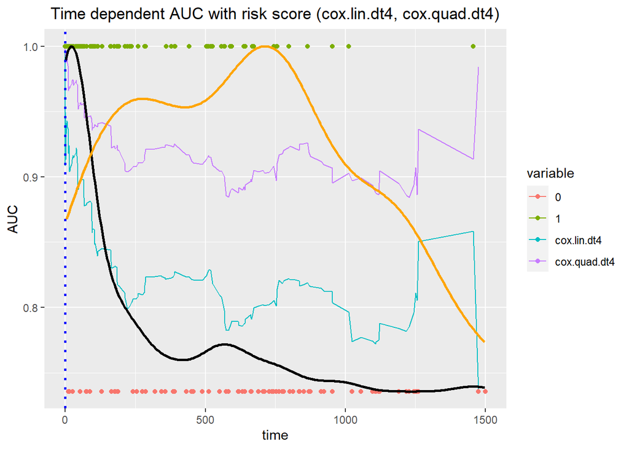

```r
dt4$censor1 <- ifelse(dt4$censor==1,
                    1,min(na.omit(ROC.risk.lin.dt4[["AUC"]])))
ggplot() +
  geom_line(data=res4, aes(x=time, y=value,
                            group=variable, color=variable)) +
  geom_point(data=dt4, aes(x=time, y=censor1, color=as.factor(censor))) +
  geom_line(data=data4_1, aes(x=time, y=density.adjusted),
            size=1, colour='black') +
  geom_line(data=data4_2, aes(x=time, y=density.adjusted),
            size=1, colour='orange') +
  scale_x_continuous(limits = c(0, max(dt4$time))) +
  geom_vline(xintercept = min(dt4$time[dt4$censor==1]),
             linetype="dotted", color = "blue", size=1) +
  ggtitle("Time dependent AUC with risk score (cox.lin.dt4, cox.quad.dt4)") +
  xlab("time") + ylab("AUC") +
  theme(plot.title = element_text(hjust = 0.5))
```

```
## geom_path: Each group consists of only one observation. Do you need to adjust
## the group aesthetic?
```

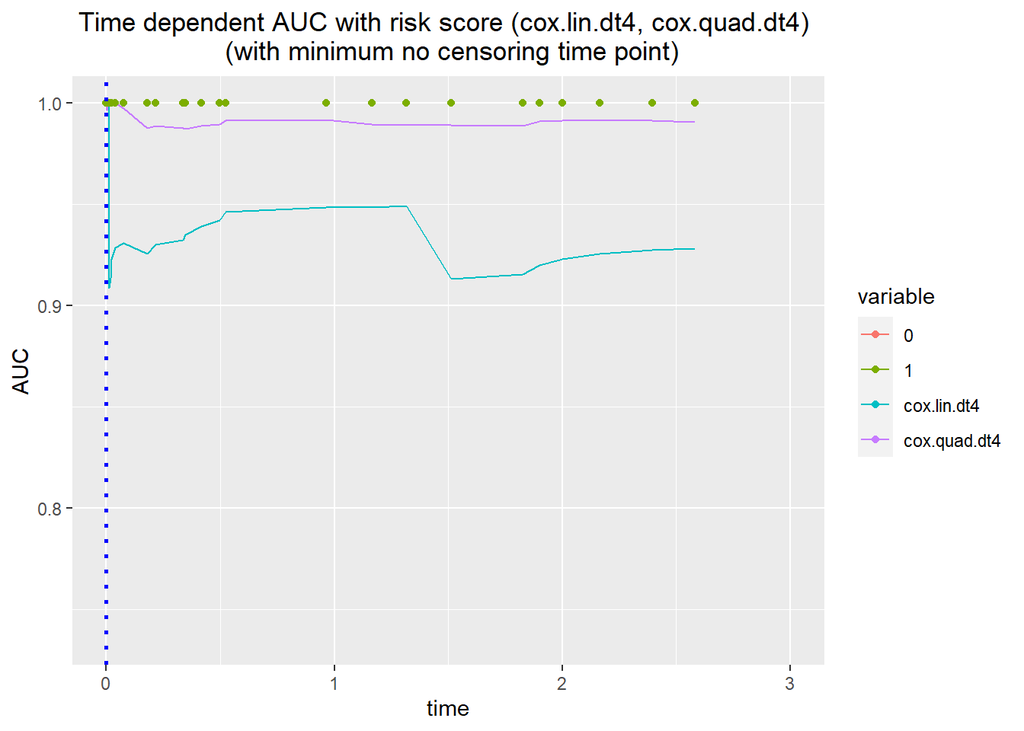

```r
ggplot() +
  geom_line(data=res4, aes(x=time, y=value,
                            group=variable, color=variable)) +
  geom_point(data=dt4, aes(x=time, y=censor1, color=as.factor(censor))) +
  geom_line(data=data4_1, aes(x=time, y=density.adjusted),
            size=1, colour='black') +
  geom_line(data=data4_2, aes(x=time, y=density.adjusted),
            size=1, colour='orange') +
  scale_x_continuous(limits = c(0, min(dt4$time[dt4$censor==1])+3)) +
  scale_y_continuous(limits = c(min(na.omit(ROC.risk.lin.dt4[["AUC"]])), 1)) +
  geom_vline(xintercept = min(dt4$time[dt4$censor==1]),
             linetype="dotted", color = "blue", size=1) +
  ggtitle("Time dependent AUC with risk score (cox.lin.dt4, cox.quad.dt4) \n (with minimum no censoring time point)") +
  xlab("time") + ylab("AUC") +
  theme(plot.title = element_text(hjust = 0.5))
```

#### Mean value of Time dependent AUC (cox.lin.dt4, cox.quad.dt4)

```r
mean(ROC.risk.lin.dt4[["AUC"]],na.rm=TRUE)
```

```
## [1] 0.8577667
```

```r
mean(ROC.risk.quad.dt4[["AUC"]],na.rm=TRUE)
```

```
## [1] 0.9387099
```

#### Counting censored data

```r
dt4.censor <- dt4[dt4$censor==0,]
dt4.censor <- dt4.censor %>%
  mutate(n.cen=cut(dt4.censor$time,
                   breaks=seq(from=0,to=1500,by=50)))
table(dt4.censor$n.cen)
```

```
##
##             (0,50]           (50,100]          (100,150]          (150,200]
##                  4                  4                  1                  6
##          (200,250]          (250,300]          (300,350]          (350,400]
##                  1                  4                  3                  4
##          (400,450]          (450,500]          (500,550]          (550,600]
##                  2                  2                  1                  3
##          (600,650]          (650,700]          (700,750]          (750,800]
##                  4                  4                  5                  4
##          (800,850]          (850,900]          (900,950]        (950,1e+03]
##                  4                  3                  2                  1
##   (1e+03,1.05e+03] (1.05e+03,1.1e+03] (1.1e+03,1.15e+03] (1.15e+03,1.2e+03]
##                  1                  2                  4                  1
## (1.2e+03,1.25e+03] (1.25e+03,1.3e+03] (1.3e+03,1.35e+03] (1.35e+03,1.4e+03]
##                  3                  3                  0                  0
## (1.4e+03,1.45e+03] (1.45e+03,1.5e+03]
##                  0                  2
```

## Compare two results

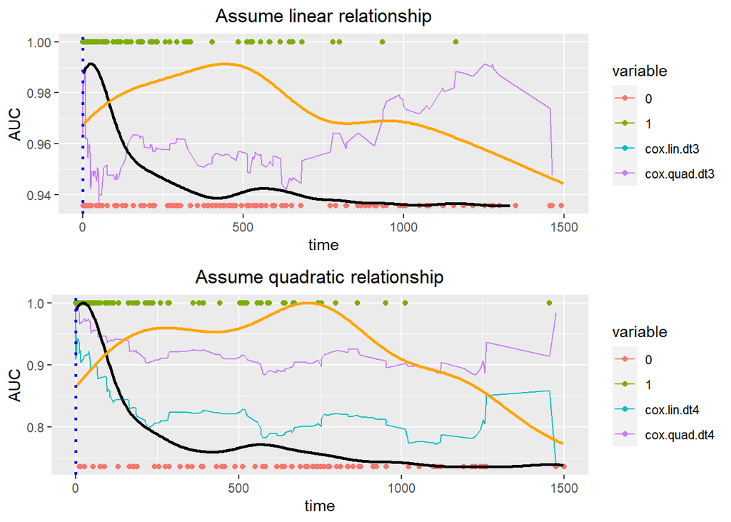

```r
a <- ggplot()

fig1 <- a +
  geom_line(data=res3, aes(x=time, y=value,
                            group=variable, color=variable)) +
  geom_point(data=dt3, aes(x=time, y=censor1, color=as.factor(censor))) +
  geom_line(data=data3_1, aes(x=time, y=density.adjusted),
            size=1, colour='black') +
  geom_line(data=data3_2, aes(x=time, y=density.adjusted),
            size=1, colour='orange') +
  scale_x_continuous(limits = c(0, 1500)) +
  geom_vline(xintercept = min(dt3$time[dt3$censor==1]),
             linetype="dotted", color = "blue", size=1) +
  ggtitle("Assume linear relationship") +
  xlab("time") + ylab("AUC") +
  theme(plot.title = element_text(hjust = 0.5))

fig2 <- a +
  geom_line(data=res4, aes(x=time, y=value,
                            group=variable, color=variable)) +
  geom_point(data=dt4, aes(x=time, y=censor1, color=as.factor(censor))) +
  geom_line(data=data4_1, aes(x=time, y=density.adjusted),
            size=1, colour='black') +
  geom_line(data=data4_2, aes(x=time, y=density.adjusted),
            size=1, colour='orange') +
  scale_x_continuous(limits = c(0, 1500)) +
  geom_vline(xintercept = min(dt4$time[dt4$censor==1]),
             linetype="dotted", color = "blue", size=1) +
  ggtitle("Assume quadratic relationship") +
  xlab("time") + ylab("AUC") +
  theme(plot.title = element_text(hjust = 0.5))

grid.arrange(fig1, fig2, nrow=2, ncol=1)
```

## simulation (repeat 100 times / time VS mean of AUC)

### Assume linear relationship

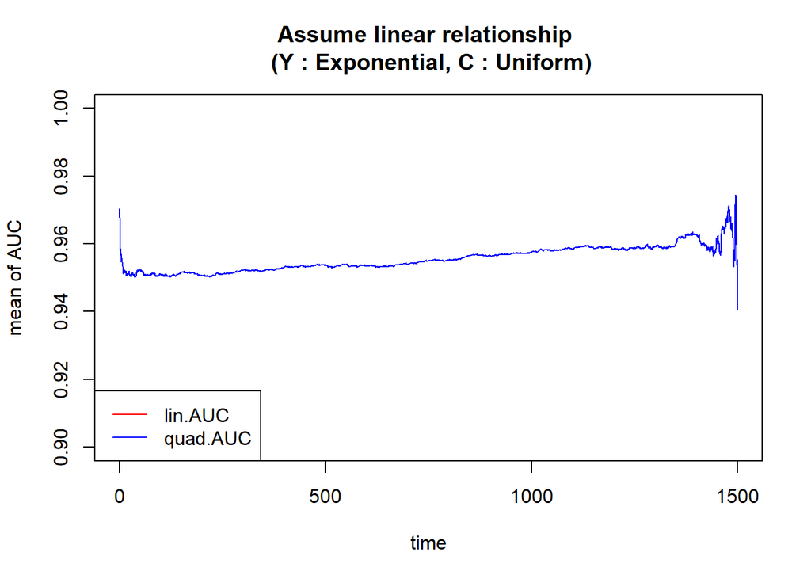

```r
lin.AUC <- matrix(nrow=length(seq(0,1500,0.2)),ncol=100)
quad.AUC <- matrix(nrow=length(seq(0,1500,0.2)),ncol=100)

for (i in 1:100) {

  # Assume parametric basis distribution is Exponential distribution...
  lambda1 <- 0.001 # parameter for generate Y
  lambda2 <- 1.5/lambda1 # parameter for generate C
  beta1 <- 3 # true coefficients
  Y <- c() # real survival time
  C <- c() # censoring time
  t <- c() # observed survival time
  censor <- c() # censoring indicator
  X <- c() # explanatory variable
  U1 <- c() # random variable from U(0,1) for generate Y
  U2 <- c() # random variable from U(0,1) for generate C
  X2 <- c() # X^2

  # Generate simulation data (Assume linear relationship)
  set.seed(i)
  for (j in 1:200) {
    U1[j] <- runif(1)
    U2[j] <- runif(1)
    X[j] <- rnorm(1,mean=0,sd=1)
    X2[j] <- X[j]^2
    Y[j] <- -(1/lambda1)*log(U1[j])*exp(-beta1*X[j])
    C[j] <- (lambda2)*(1-U2[j])
    t[j] <- min(Y[j],C[j])
    censor[j] <- ifelse(Y[j]<=C[j],1,0)
  }
  dt3 <- data.frame(X=X, X2=X2, Y=Y, C=C, time=t, censor=censor)

  # Set linear model
  cox.lin.dt3 <- coxph(Surv(time,censor) ~ X, data=dt3)
  risk.lin.dt3 <- predict(object=cox.lin.dt3, newdata=dt3, type="risk")
  dt3$risk.lin.dt3 <- risk.lin.dt3
  ROC.risk.lin.dt3 <- timeROC(T=dt3$time,
                         delta=dt3$censor,marker=dt3$risk.lin.dt3,
                         cause=1,weighting="marginal",
                         times=seq(0,1500,0.2))

  # Set quadratic model
  cox.quad.dt3 <- coxph(Surv(time,censor) ~ X+X2, data=dt3)
  risk.quad.dt3 <- predict(object=cox.quad.dt3, newdata=dt3, type="risk")
  dt3$risk.quad.dt3 <- risk.quad.dt3
  ROC.risk.quad.dt3 <- timeROC(T=dt3$time,
                         delta=dt3$censor,marker=dt3$risk.quad.dt3,
                         cause=1,weighting="marginal",
                         times=seq(0,1500,0.2))

  lin.AUC[,i] <- ROC.risk.lin.dt3[["AUC"]]
  quad.AUC[,i] <- ROC.risk.quad.dt3[["AUC"]]

  # print(i)

}

dat3 <- data.frame(time=seq(0,1500,0.2), lin.AUC=rowMeans(lin.AUC, na.rm=TRUE),
                   quad.AUC=rowMeans(quad.AUC, na.rm=TRUE))
plot(x=dat3$time, y=dat3$lin.AUC, xlab="time", ylab="mean of AUC",
     main="Assume linear relationship \n (Y : Exponential, C : Uniform)", type="l", col="red", ylim=c(0.9,1))
lines(x=dat3$time, y=dat3$quad.AUC, type="l", col="blue")
legend("bottomleft",c("lin.AUC","quad.AUC"),col=c("red","blue"),lty=c(1,1))
```

### Assume quadratic relationship

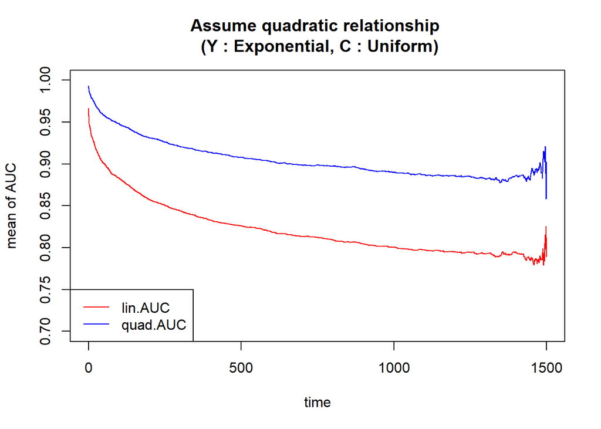

```r
lin.AUC <- matrix(nrow=length(seq(0,1500,0.2)),ncol=100)
quad.AUC <- matrix(nrow=length(seq(0,1500,0.2)),ncol=100)

for (i in 1:100) {

  # Assume parametric basis distribution is Exponential distribution...
  lambda1 <- 0.001 # parameter for generate Y
  lambda2 <- 1.5/lambda1 # parameter for generate C
  beta1 <- 3 ; beta2 <- 2 # true coefficients
  Y <- c() # real survival time
  C <- c() # censoring time
  t <- c() # observed survival time
  censor <- c() # censoring indicator
  X <- c() # explanatory variable
  U1 <- c() # random variable from U(0,1) for generate Y
  U2 <- c() # random variable from U(0,1) for generate C
  X2 <- c() # X^2

  # Generate simulation data (Assume quadratic relationship)
  set.seed(i)
  for (j in 1:200) {
    U1[j] <- runif(1)
    U2[j] <- runif(1)
    X[j] <- rnorm(1,mean=0,sd=1)
    X2[j] <- X[j]^2
    Y[j] <- -(1/lambda1)*log(U1[j])*exp(-beta1*X[j]-beta2*X2[j])
    C[j] <- (lambda2)*(1-U2[j])
    t[j] <- min(Y[j],C[j])
    censor[j] <- ifelse(Y[j]<=C[j],1,0)
  }
  dt4 <- data.frame(X=X, X2=X2, Y=Y, C=C, time=t, censor=censor)

  # Set linear model
  cox.lin.dt4 <- coxph(Surv(time,censor) ~ X, data=dt4)
  risk.lin.dt4 <- predict(object=cox.lin.dt4, newdata=dt4, type="risk")
  dt4$risk.lin.dt4 <- risk.lin.dt4
  ROC.risk.lin.dt4 <- timeROC(T=dt4$time,
                         delta=dt4$censor,marker=dt4$risk.lin.dt4,
                         cause=1,weighting="marginal",
                         times=seq(0,1500,0.2))

  # Set quadratic model
  cox.quad.dt4 <- coxph(Surv(time,censor) ~ X+X2, data=dt4)
  risk.quad.dt4 <- predict(object=cox.quad.dt4, newdata=dt4, type="risk")
  dt4$risk.quad.dt4 <- risk.quad.dt4
  ROC.risk.quad.dt4 <- timeROC(T=dt4$time,
                         delta=dt4$censor,marker=dt4$risk.quad.dt4,
                         cause=1,weighting="marginal",
                         times=seq(0,1500,0.2))

  lin.AUC[,i] <- ROC.risk.lin.dt4[["AUC"]]
  quad.AUC[,i] <- ROC.risk.quad.dt4[["AUC"]]

  # print(i)

}

dat4 <- data.frame(time=seq(0,1500,0.2), lin.AUC=rowMeans(lin.AUC, na.rm=TRUE),
                   quad.AUC=rowMeans(quad.AUC, na.rm=TRUE))
plot(x=dat4$time, y=dat4$lin.AUC, xlab="time", ylab="mean of AUC",
     main="Assume quadratic relationship \n (Y : Exponential, C : Uniform)", type="l", col="red", ylim=c(0.7,1))
lines(x=dat4$time, y=dat4$quad.AUC, type="l", col="blue")
legend("bottomleft",c("lin.AUC","quad.AUC"),col=c("red","blue"),lty=c(1,1))
```